# 438485_kod

Krzysztof Hajderek

2024-04-09

Zadanie 1. Wczytujemy dane:

```r
x_test <- read.csv("X_test.csv")
x_train <- read.csv("X_train.csv")
y <- read.csv("y_train.csv")
y <- y$CD36
```

Sprawdzamy strukturę danych i czy nie ma braków:

```r
anyNA.data.frame(x_train)
```

```
## [1] FALSE
```

```r
anyNA.data.frame(x_test)
```

```
## [1] FALSE
```

```r
anyNA(y)
```

```
## [1] FALSE
```

```r
str(x_test)
```

```
## 'data.frame':    1200 obs. of  9000 variables:
##  $ LINC01409   : num  0 0 0 0 0 0 0 0 0 0 ...
##  $ LINC01128   : num  0 0 0 0 0 ...
##  $ LINC00115   : num  0 0 0 0 0 0 0 0 0 0 ...
##  $ NOC2L       : num  0 0 0 0 0 ...
##  $ KLHL17      : num  0 0 0 0 0 0 0 0 0 0 ...
##  $ HES4        : num  0 0 0 0 0 0 0 0 0 0 ...
##  $ ISG15       : num  0 0 0.935 0.76 0 ...
##  $ C1orf159    : num  0 0 0 0 0 0 0 0 0 0 ...
##  $ TNFRSF18    : num  0 0 0 0 0 0 0 0 0 0 ...
##  $ TNFRSF4     : num  0 0 0 0 0 0 0 0 0 0 ...
##  $ SDF4        : num  0 0.824 0 0 0 ...
##  $ C1QTNF12    : num  0 0 0 0 0 0 0 0 0 0 ...
##  $ UBE2J2      : num  0.581 0 0 0 0 ...
##  $ INTS11      : num  0 0 0 0 0 0 0 0 0 0 ...
```

[output cut: 86 more lines]

```r
str(x_train)
```

```
## 'data.frame':    6800 obs. of  9000 variables:
##  $ LINC01409   : num  0 0 0 0 0 0 0 0 0 0 ...
##  $ LINC01128   : num  0 0 0 0 0 0 0 0 0 0 ...
##  $ LINC00115   : num  0 0 0 0 0 0 0 0 0 0 ...
##  $ NOC2L       : num  0 0 0 0 0 0 0 0 0 0 ...
##  $ KLHL17      : num  0 0 0 0 0 0 0 0 0 0 ...
##  $ HES4        : num  0 0 0 0 0 ...
##  $ ISG15       : num  0 0 0.68 0.478 0 ...
##  $ C1orf159    : num  0 0 0 0 0 0 0 0 0 0 ...
##  $ TNFRSF18    : num  0 0 0 0 0 0 0 0 0 0 ...
##  $ TNFRSF4     : num  0 0 0 0 0 0 0 0 0 0 ...
##  $ SDF4        : num  0 0 0 0.478 1.058 ...
##  $ C1QTNF12    : num  0 0 0 0 0 0 0 0 0 0 ...
##  $ UBE2J2      : num  0 0 0 0 0.663 ...
##  $ INTS11      : num  0 0 0 0 0 ...
```

[output cut: 86 more lines]

```r
str(y)
```

```
##  num [1:6800] 1.84 2.36 2.06 3.47 3.05 ...
```

Widzimy, że nie ma braków.

Podstawowe statystyki zmiennej objaśnianej:

```r
print(var(y))
```

```
## [1] 1.330415
```

```r
summary(y)
```

```
##    Min. 1st Qu.  Median    Mean 3rd Qu.    Max.
##   0.000   0.000   0.526   1.086   1.972   5.768
```

Estymator gęstości:

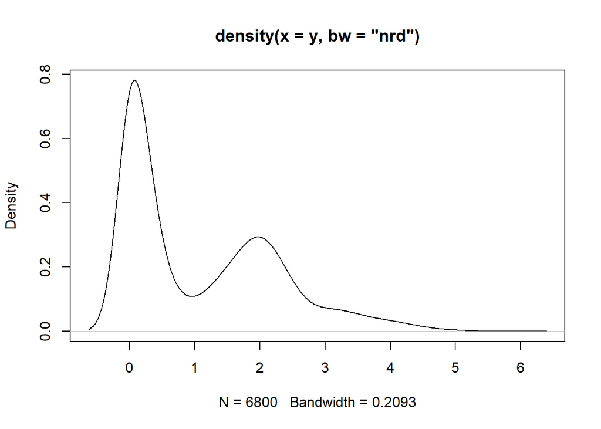

```r
plot(density(y, bw = 'nrd'))
```

Wybieramy 250 zmiennych objaśniających najbardziej skorelowanych ze zmienną objaśnianą:

```r
cor_y = function(x) cor(x, y, method = "pearson")
cors = apply(x_train, 2, cor_y)
cors = sort(cors, decreasing = TRUE)
most_correlated = x_train[,names(cors)[1:250]]
```

Liczymy korelację dla każdej z par tych zmiennych:

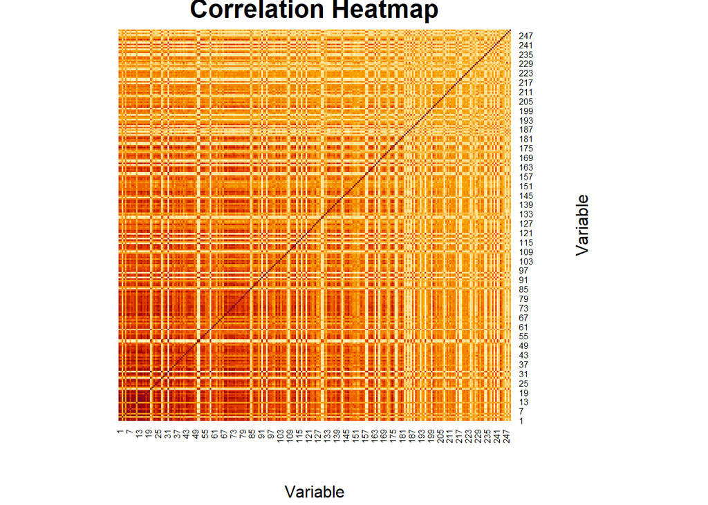

```r
n = ncol(most_correlated)
correlations = matrix(nrow = n, ncol = n)
for (i in 1:n){
  for(j in 1:n){
    correlations[i, j] = cor(most_correlated[,i], most_correlated[,j], method = "pearson")
  }
}

heatmap(correlations,
        Rowv = NA,
        Colv = NA,
        scale = "none",
        xlab = "Variable",
        ylab = "Variable",
        main = "Correlation Heatmap")
```

Zadanie 2. a)

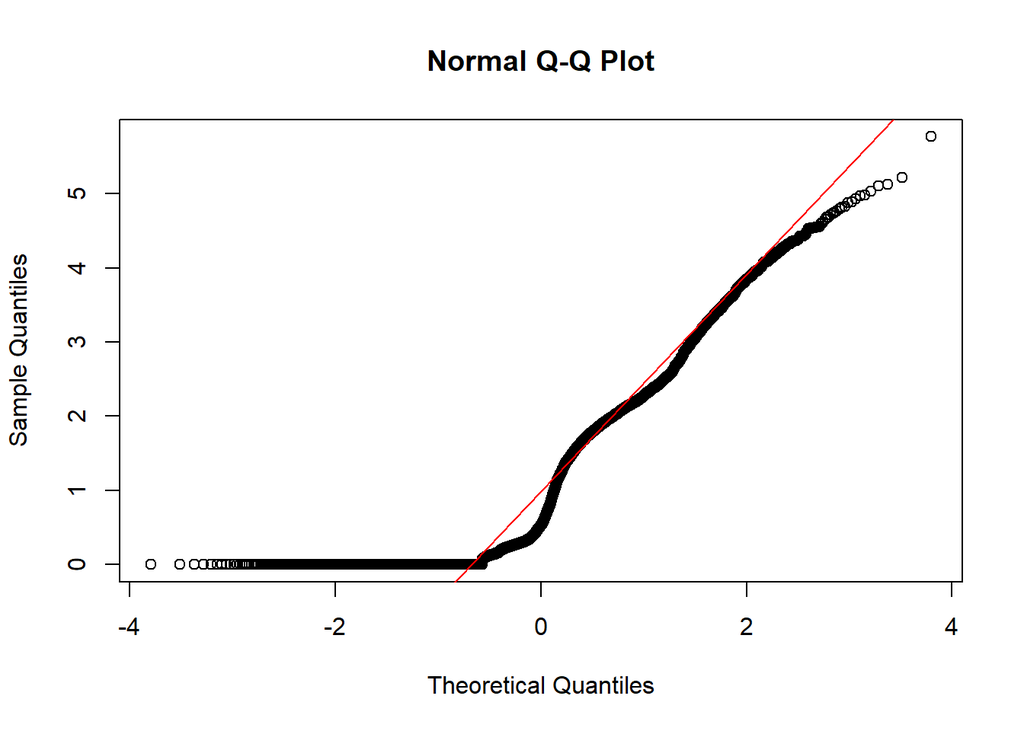

```r
qqnorm(y)
qqline(y, col = "red")
```

Nie można w prosty sposób odczytać tych parametrów, ponieważ wykres nie jest prostą. b) Niech $H_0$: próbka pochodzi z pewnego rozkładu normalnego, $H_1$: $\sim H_0$. Zweryfikujemy hipotezę przy pomocy testu Andersona-Darlinga na poziomie istotności 0.01.

```r
library(nortest)
ad.test(y)
```

```
##
##  Anderson-Darling normality test
##
## data:  y
## A = 358.85, p-value < 2.2e-16
```

P - wartość jest poniżej 0.01, więc odrzucamy $H_0$. c) Wybieramy zmienną najbardziej skorelowaną ze zmienną objaśnianą i rysujemy wykres estymatora gęstości.

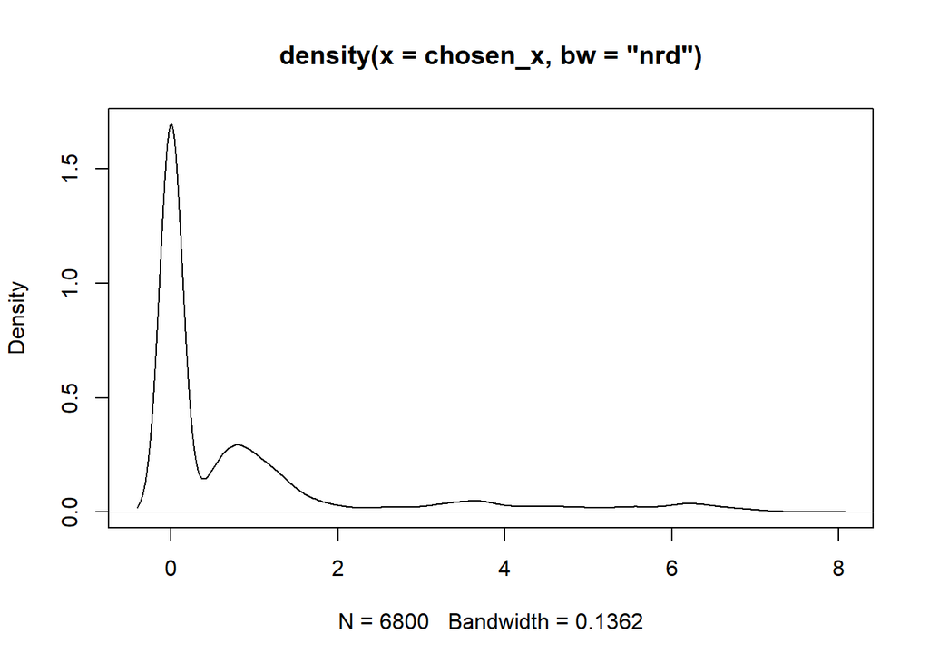

```r
chosen_x = x_train[,names(cors)[1]]
d = density(chosen_x, bw = 'nrd')
plot(d)
```

```r
library(nortest)
ad.test(chosen_x)
```

```
##
##  Anderson-Darling normality test
##
## data:  chosen_x
## A = 1020.3, p-value < 2.2e-16
```

P - wartość jest poniżej 0.01, więc odrzucamy $H_0$.

Zadanie 3. a) ElasticNet to model regresji liniowej, który łączy właściwości regresji grzbietowej (ridge regression) i regresji lasso (Least Absolute Shrinkage and Selection Operator). Jego głównym celem jest jednoczesna selekcja cech oraz regularyzacja modelu, co pozwala na uzyskanie bardziej stabilnych i interpretowalnych wyników w przypadku danych o wysokiej kolinearności.

Funkcja, którą optymalizuje model ElasticNet, jest zdefiniowana jako:

$$\min_{\beta_0, \beta} \left\{ \frac{1}{2N} \sum_{i=1}^{N} (yi - \beta_0
- \mathbf{x}_i^T \beta)^2 + \lambda \left( \alpha \|\beta\|_1 +
\frac{1-\alpha}{2} \|\beta\|_2^2 \right) \right\}$$

gdzie: - $yi$ to wartości zmiennej objaśnianej, - $\mathbf{x}_i$ to wektor cech dla obserwacji $i$,

Model ElasticNet estymuje następujące parametry: - $\beta_0$ - wyraz wolny modelu, - $\beta_1, \beta_2, \ldots, \beta_p$ - współczynniki regresji dla każdej z $p$ cech.

ElasticNet posiada dwa hiperparametry: - $\lambda$ - parametr regularyzacji, który decyduje o łącznej sile regularyzacji, - $\alpha$ - parametr mieszania, który kontroluje równowagę między regularyzacją L1 i L2.

Dla różnych wartości hiperparametrów model ElasticNet przyjmuje postać regresji grzbietowej lub lasso: - Gdy $\alpha = 0$, model staje się regresją grzbietową (ridge regression), a - Gdy $\alpha = 1$, model staje się regresją lasso

2. Użyjemy 10-fold, aby uzyskać balans między minimalizowaniem wariancji i zwiększaniem elastyczności.

```r
library(glmnet)
x = data.matrix(x_train)
nfolds = 10
foldid = sample(cut(1:nrow(x), nfolds, labels = F))
alphas = seq(from = 0, to = 1, by = 0.5)
lambdas = seq(from = 0.5, to = 1.5, by = 0.5)
new_array = function() array(dim = c(length(alphas), length(lambdas), nfolds))
validation_errors = new_array()
train_errors = numeric(nfolds)
min_error = Inf
for (i in 1:length(alphas)){
  for (j in 1:length(lambdas)){
    test_errors = numeric(nfolds)
    for (k in 1:nfolds){
      train = which(foldid != k)
      model = glmnet(x[train,], y[train], lambda = lambdas[j], alpha = alphas[i], family = "gaussian")
      predicted = predict(model, newx = x, type = "response")
      validation_errors[i, j, k] = mean((predicted[-train]-y[-train])^2)
      train_errors[k] = mean((predicted[train]-y[train])^2)
    }
    validation_error = mean(validation_errors[i,j,])
    if (validation_error < min_error){
        which_alpha_best = i
        which_lambda_best= j
        min_error = validation_error
        train_error = mean(train_errors) #train error in best model
      }
  }
}
alphas[which_alpha_best]
```

```
## [1] 0
```

```r
lambdas[which_lambda_best]
```

```
## [1] 1.5
```

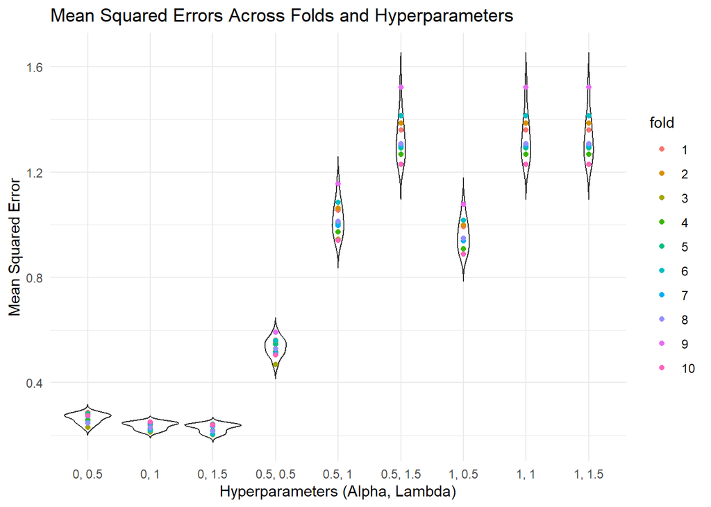

```r
library(ggplot2)

alpha = new_array()
lambda = new_array()
fold = new_array()

for (i in 1:length(alphas)){
  for (j in 1:length(lambdas)){
    for (k in 1:nfolds){
      alpha[i, j,k] = alphas[i]
      lambda[i,j,k] = lambdas[j]
      fold[i, j, k] = k
    }
  }
}

al = as.vector(alpha)
la = as.vector(lambda)
params = character(length(al))
for (i in 1:length(al)){
  params[i] = paste0(al[i], ", ", la[i])
}

dat = data.frame(
  parameters = factor(params),
  fold = factor(as.vector(fold)),
  mse = as.vector(validation_errors))

ggplot(dat) +
  geom_violin(aes(x = parameters, y = mse), trim = FALSE) +
  geom_point(aes(x=parameters, y = mse, color = fold)) +
  labs(title = "Mean Squared Errors Across Folds and Hyperparameters",
       x = "Hyperparameters (Alpha, Lambda)", y = "Mean Squared Error") +
  theme_minimal()
```

```r
train_error
```

```
## [1] 0.08344015
```

```r
mean(validation_errors[which_alpha_best, which_lambda_best,])
```

```
## [1] 0.2273752
```

Zadanie 4. a)

```r
library(randomForest)
p = ncol(x)
tree_numbers = c(5, 10)
m_try = c(5, 10)
nodesizes = c(5, 10)

new_array2 = function() array(dim = c(2, 2, 2, 10))
validation_errors_forest = new_array2()
min_error = Inf
for (h in 1:length(tree_numbers)){
  for (i in 1:length(m_try)){
    for (j in 1:length(nodesizes)){
      test_errors = numeric(nfolds)
      for (k in 1:nfolds){
        train = which(foldid != k)
        model = randomForest(x[train,], y[train], ntree = tree_numbers[h], mtry = m_try[i], nodesize = nodesizes[j])
        predicted = predict(model, x)
        validation_errors_forest[h, i, j, k] = mean((predicted[-train]-y[-train])^2)
        train_errors[k] = mean((predicted[train]-y[train])^2)
      }
      validation_error = mean(validation_errors_forest[h,i,j,])
      if (validation_error < min_error){
          opt_params_forest = c(h, i, j)
          min_error = validation_error
          train_error_forest = mean(train_errors) #train error in best model
        }
    }
  }
}
tree_numbers[opt_params_forest[1]]
```

```
## [1] 10
```

```r
m_try[opt_params_forest[2]]
```

```
## [1] 10
```

```r
nodesizes[opt_params_forest[3]]
```

```
## [1] 5
```

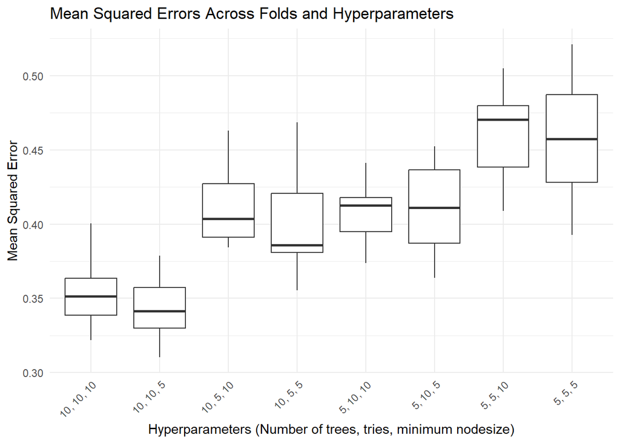

```r
tree_number = new_array2()
mt = new_array2()
nodesize = new_array2()

for (h in 1:length(tree_numbers)){
  for (i in 1:length(m_try)){
    for (j in 1:length(nodesizes)){
      for (k in 1:nfolds){
        tree_number[h, i, j, k] = tree_numbers[h]
        mt[h, i, j, k] = m_try[i]
        nodesize[h, i, j, k] = nodesizes[j]
      }
    }
  }
}

tree_number = as.vector(tree_number)
mt = as.vector(mt)
nodesize = as.vector(nodesize)
params = character(length(tree_number))
for (i in 1:length(tree_number)){
  params[i] = paste0(tree_number[i], ", ", mt[i], ", ", nodesize[i])
}

dat = data.frame(
  parameters = factor(params),
  mse = as.vector(validation_errors_forest))

library(ggplot2)
ggplot(dat) +
  geom_boxplot(aes(x = parameters, y = mse), outlier.shape = NA) +
  labs(title = "Mean Squared Errors Across Folds and Hyperparameters",
       x = "Hyperparameters (Number of trees, tries, minimum nodesize)", y = "Mean Squared Error") +
  theme_minimal() +
  theme(axis.text.x = element_text(angle = 45, hjust = 1))
```

c)

```r
train_error_forest
```

```
## [1] 0.09147925
```

```r
mean(validation_errors_forest[opt_params_forest[1], opt_params_forest[2], opt_params_forest[3],])
```

```
## [1] 0.350127
```

Zadanie 5.

```r
err_net = validation_errors[which_alpha_best, which_lambda_best,]
err_forest = validation_errors_forest[opt_params_forest[1], opt_params_forest[2], opt_params_forest[3],]
err_ref = numeric(nfolds)

for (k in 1:nfolds){
        train = which(foldid != k)
        prediction = mean(y[train])
        err_ref[k] = mean((y[-train] - prediction)^2)
}

mean_err_net = mean(err_net)
mean_err_forest = mean(err_forest)
mean_err_ref = mean(err_ref)
results <- data.frame(
Fold = 1,
ElasticNet = err_net,
RandomForest = err_forest,
ReferenceModel = err_ref
)

mean_results <- data.frame(
Model = c("ElasticNet", "Random Forest", "Reference Model"),
Mean_MSE = c(mean_err_net, mean_err_forest, mean_err_ref)
)
```